# Visualizations with ggplot

Advanced PD Lab 2B

The following slides contain information and examples about how to create visualizations using ggplot. You will need your ggplot CHEAT SHEET.

# What is ggplot?

The ggplot package, created by [Hadley Wickham](http://hadley.nz/), Chief Scientist at RStudio, offers a powerful graphics language for creating elegant and complex plots.

ggplot allows you to create graphs that represent both univariate and multivariate numerical and categorical data in a straightforward manner.

**Let’s get started:**

Begin by installing and loading the `ggplot` package.

`install.packages(" ")`

`library( )`

### Consider Data:

Load and preview the `mpg` data.

# Categorical Variables

The template to create a visual in ggplot looks like:

```
ggplot(data = < DATA >) +

< GEOM_FUNCTION >(mapping = aes(< MAPPINGS >))
```

**Include all of the codes you come across in an RMarkdown:**

**Cheat Sheet**

**ONE VARIABLE discrete**

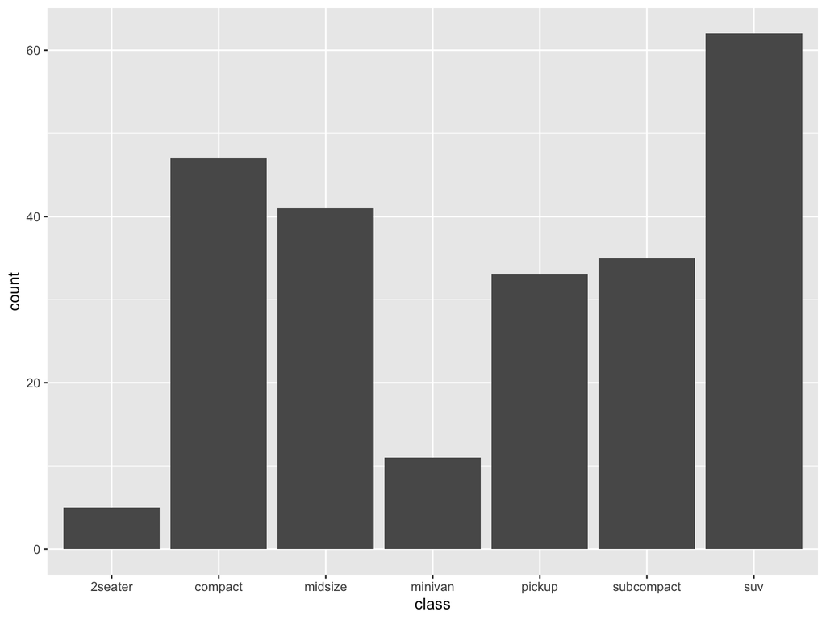

```r
ggplot(data = mpg) +
  geom_bar(mapping = aes(x = class))
```

The following arguments can be applied to change the color of a visual: `color, fill`

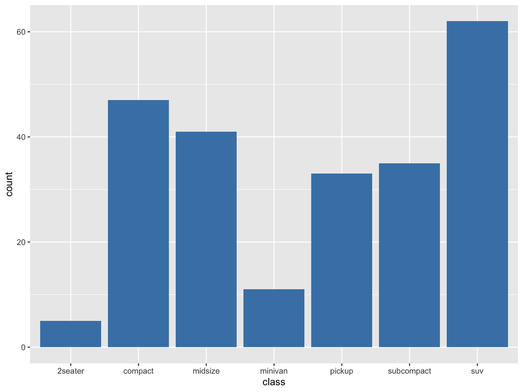

```r
ggplot(data = mpg) +
  geom_bar(mapping = aes(x = class), fill="steelblue")
```

**1. Replace the `fill` argument with `color` and explain how it affects the visual.**

**2. What code will create the visual below?**

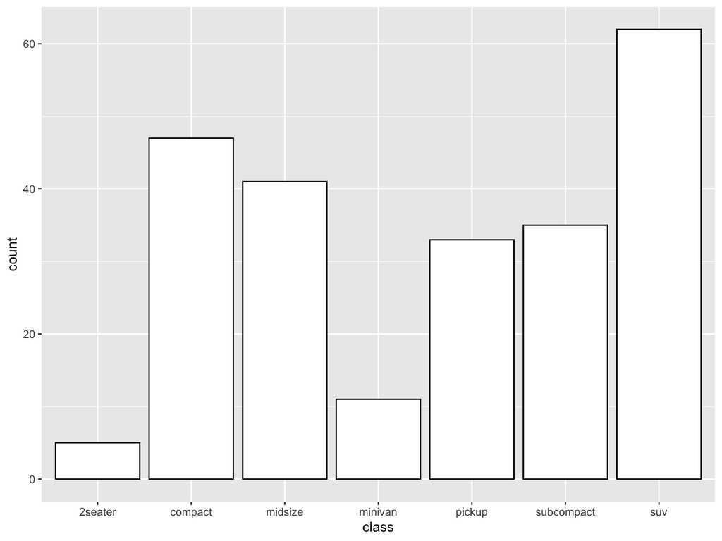

The `fill` argument can also be used to assign colors to each category of a categorical variable (similar to what the groups argument does in lattice). Notice that the argument needs to be contained within the aesthetics.

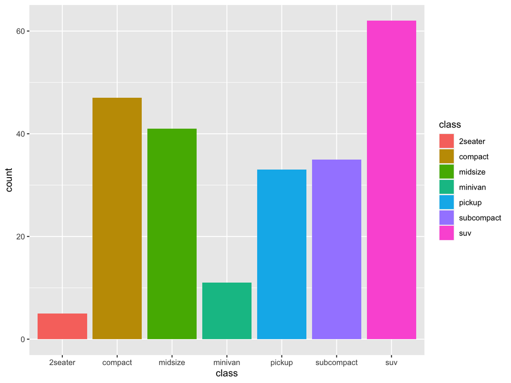

```r
ggplot(data = mpg) +
  geom_bar(mapping = aes(x = class, fill=class))
```

Let’s add more layers to this visual.

**CHEAT SHEET**

**Scales, Labels, Coordinate Systems and Themes**

Functions from Scales, Labels, Coordinate Systems and Themes have been applied to modify the visual.

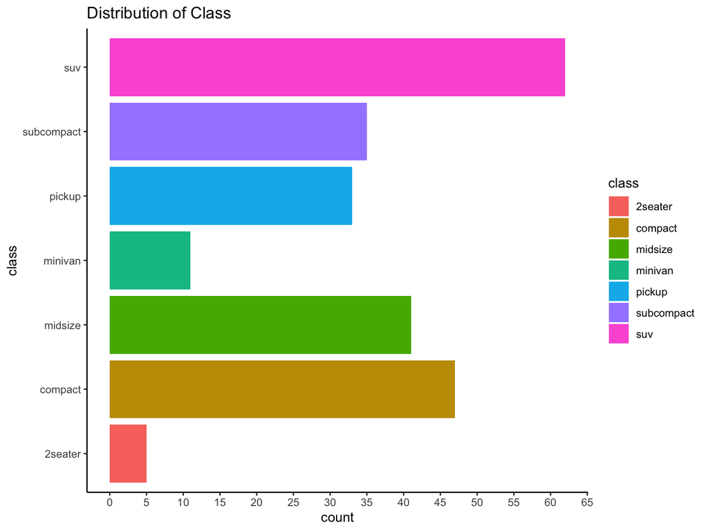

```r
ggplot(data = mpg) +
  geom_bar(mapping = aes(x = class, fill = class)) +
  scale_y_continuous(breaks = seq(0, 70, 5))+
  labs(title ="Distribution of Class") +
  coord_flip ()+
  theme_classic ()
```

**Flex Your Skills:**

**3. Modify the visual above by changing the scale, including additional labels and changing the theme.**

# Comparing Groups on a Categorical Variable

**Is there a difference in the number of cylinders between types of cars?**

In order to create a visual to compare groups using lattice, we utilized the vertical bar (`|`) to split or facet each groups’ data into a separate graph. The `groups` argument color coded the groups.

ggplot offers similar options with their `Faceting` and `Position Adjustment` options.

**NOTE:** If you look at the structure of the mpg data you will find that the variable `cyl`is being interpreted as an integer. We, however, are utilizing it more as a categorical variable so we need to mutate the data using the following code:

```r
mpg<-mutate(mpg, cyl=as.factor(cyl))
```

Let’s look at the most basic code in ggplot2 for creating a bargraph comparing groups…in this case the number of cylinders between type of car.

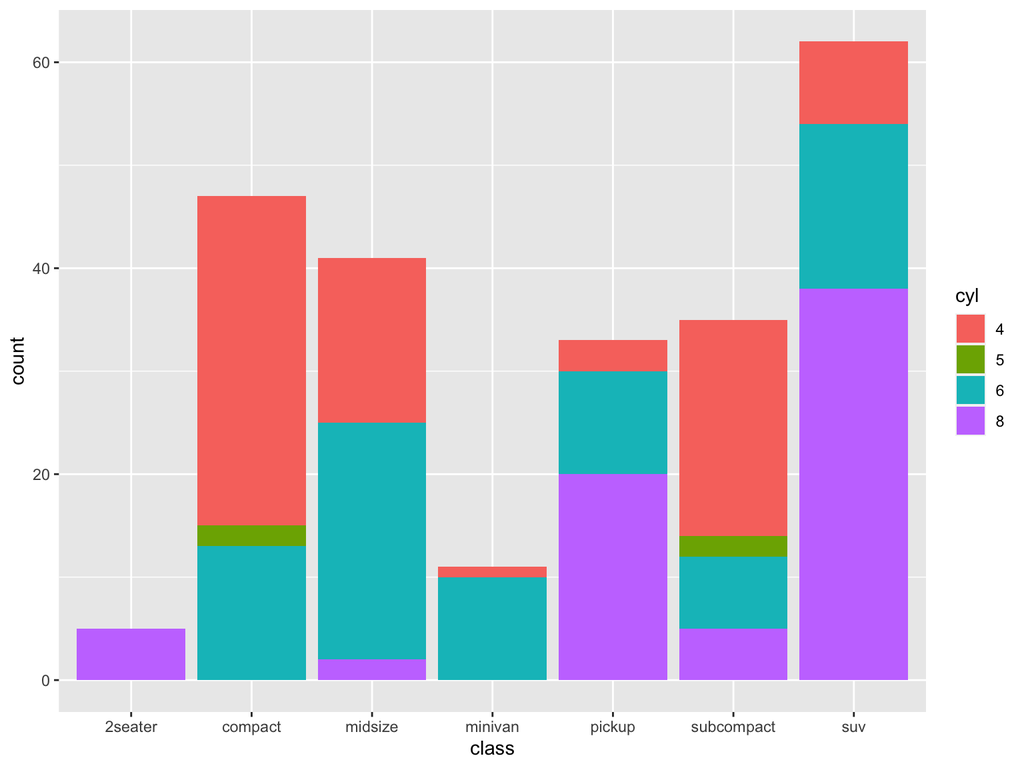

```r
ggplot(data = mpg) +
  geom_bar(mapping = aes(x = class,fill=cyl))
```

4. **What do you predict will happen if you swap `class` and `cyl` in the code above? Check if your prediction is correct.**

Let’s see the different ways we can facet the visuals!

**Cheat Sheet**

**Faceting**

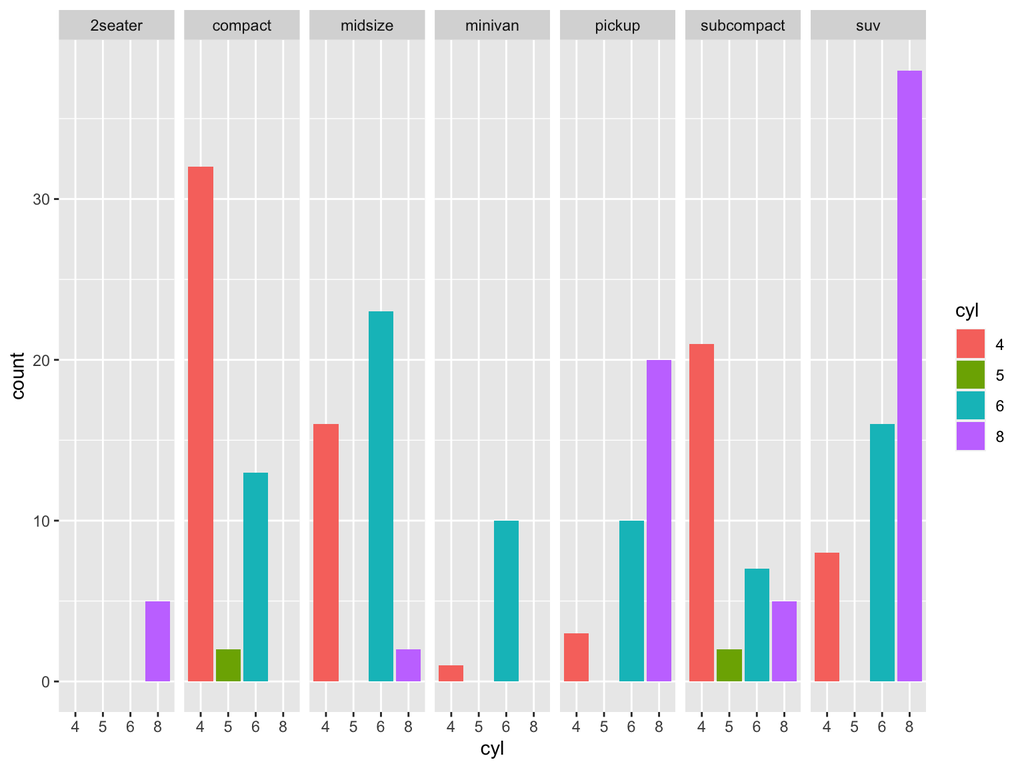

```r
ggplot(data = mpg) +
  geom_bar(mapping = aes(x = cyl,fill=cyl))+
  facet_grid(cols=vars(class))
```

**5. What code will create the visual below?**

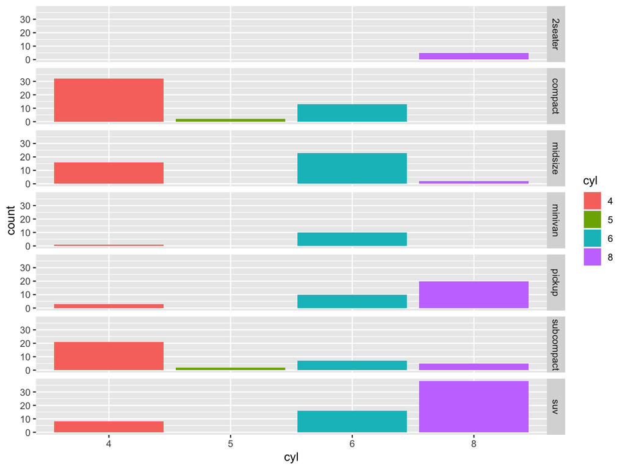

**6. What code will create the visual below?**

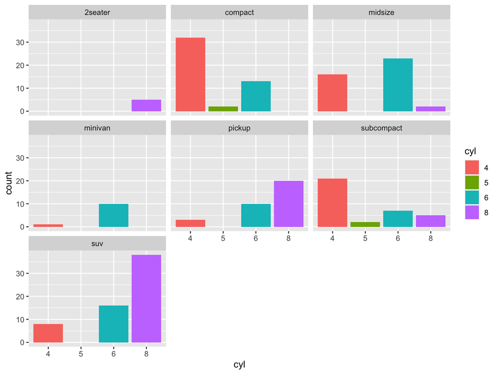

Let’s see what the position functions do!

**Cheat Sheet**

**Position Adjustments**

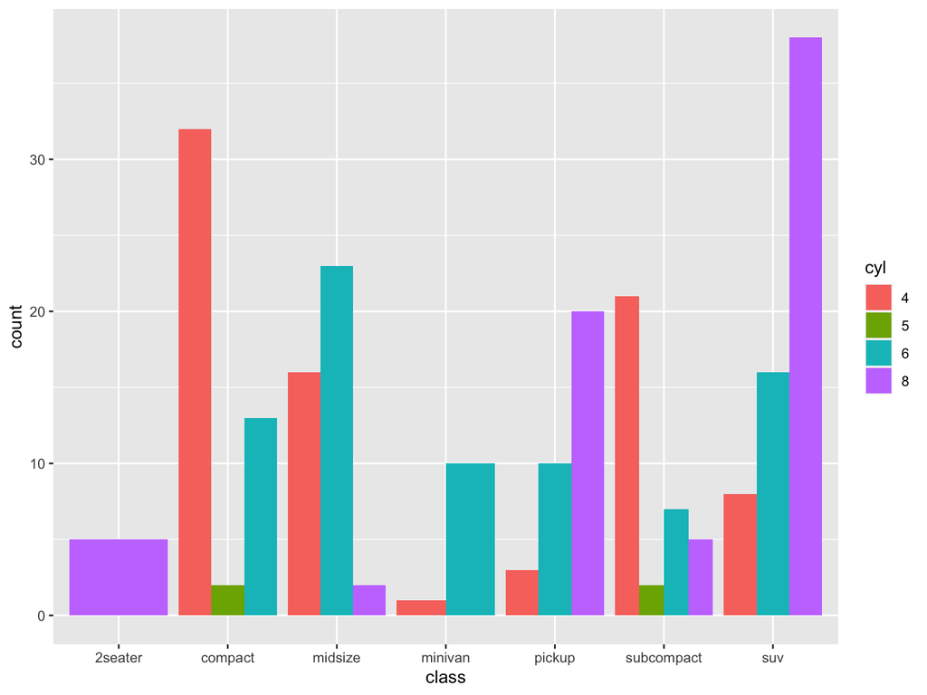

```r
ggplot(data = mpg) +
  geom_bar(mapping = aes(x = class,fill=cyl),position="dodge")
```

**7. What do you predict will happne if you swap `class` and `cyl` in the code above? Check and see if your prediction was correct.**

Let’s look at the `fill` position.

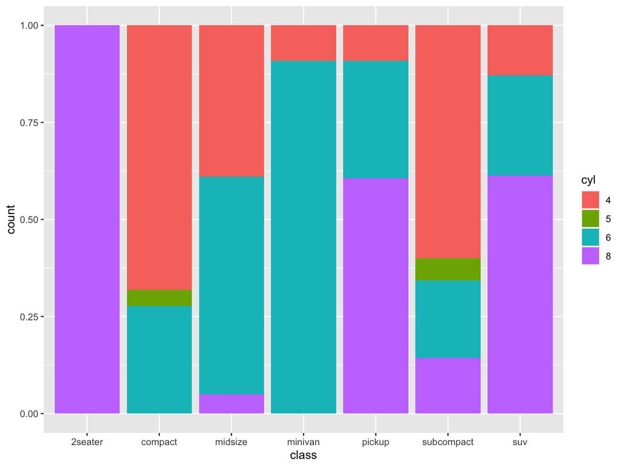

```r
ggplot(data = mpg) +
  geom_bar(mapping = aes(x = class,fill=cyl), position="fill")
```

**8. When might we want to use the `fill` position?**

# Numerical Variables

**CHEAT SHEET**

ONE VARIABLE continuous

Let’s look at a basic histogram.

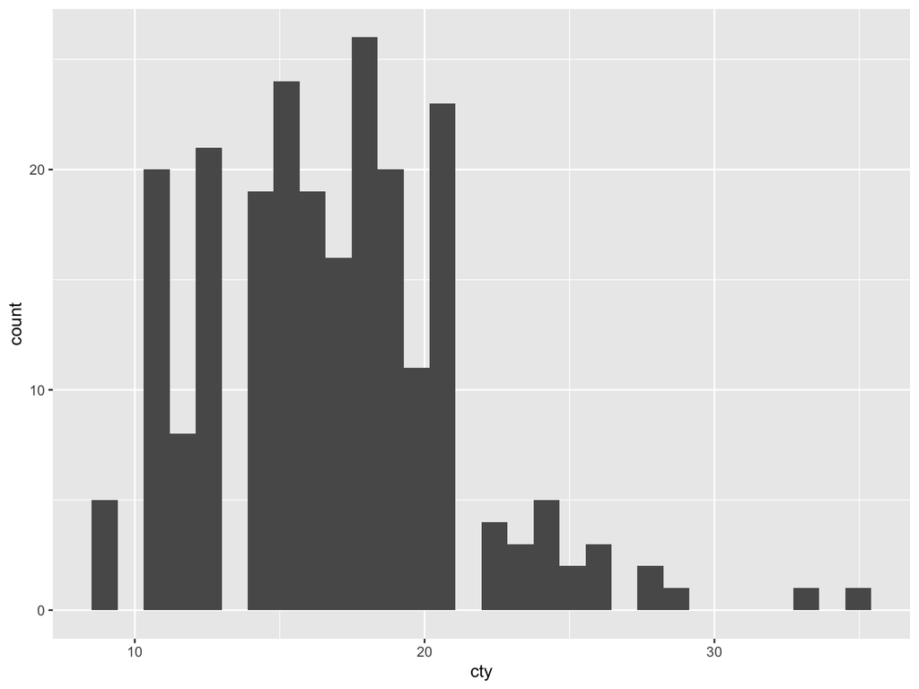

```r
ggplot(data=mpg)+
  geom_histogram(mapping=aes(x=cty))
```

Notice that a histogram was created but the computer was not happy about the number of bins (30). This histogram is behaving more like a dotplot because there is a bin for each value of city miles per gallon. The `binwidth` argument works similar to the `nint` argument in lattice. Currenlty there is one bin for each value (binwidth=1).

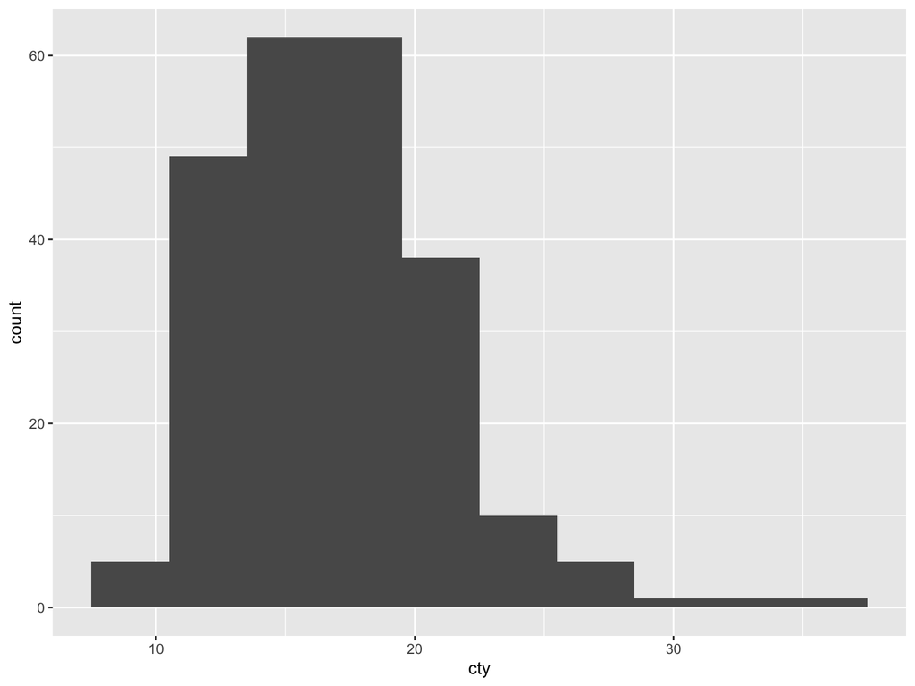

```r
ggplot(data=mpg)+
  geom_histogram(mapping=aes(x=cty),binwidth = 3)
```

**9. What code will create the visual below?**

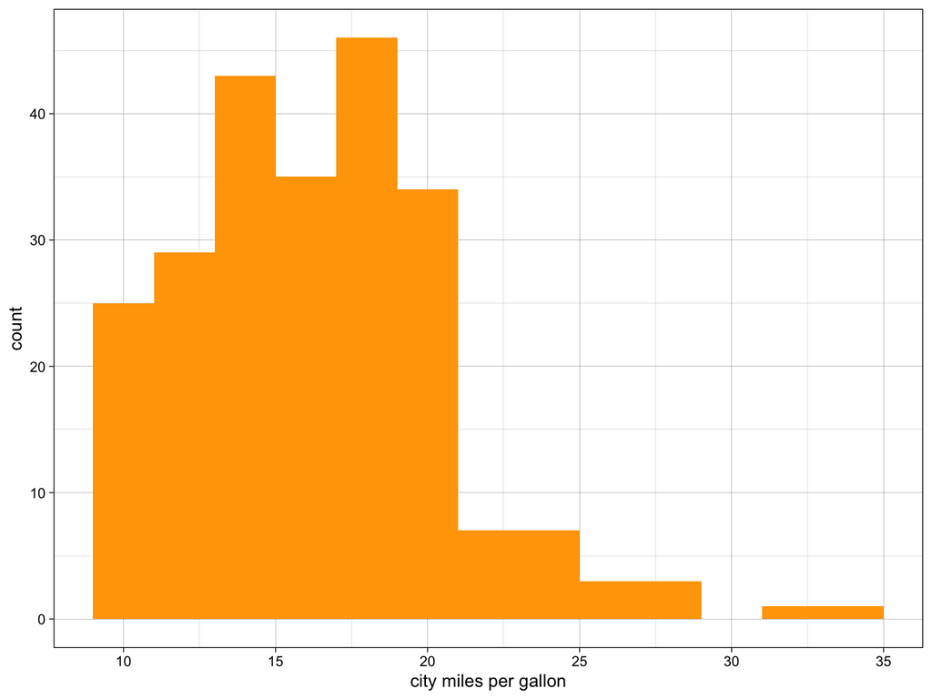

ggplot allows us to overlay plots!

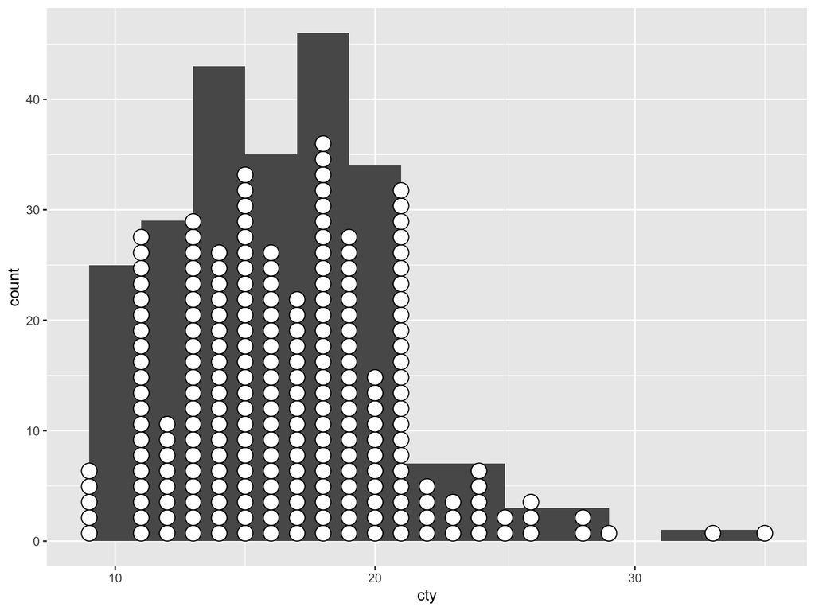

```r
ggplot(data=mpg)+
  geom_histogram(mapping=aes(x=cty),binwidth = 2)+
  geom_dotplot(mapping=aes(x=cty),fill="white",binwidth = 0.6)
```

**10. Change the order of the plots for the code above and explain what happens?**

**11. What code will create the visual below?**

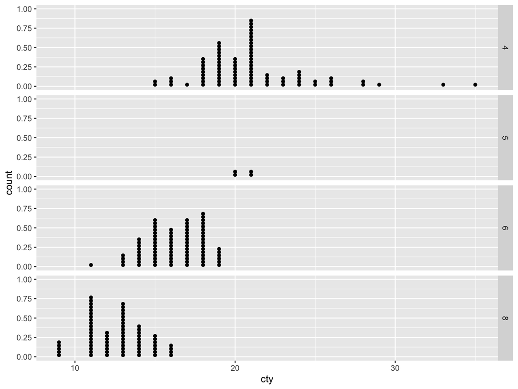

# TWO VARIABLES

**CHEAT SHEET**

**discrete x, continuous y**

Notice that the geom_boxplot() function calls for a discrete variable and a continuous variable. The geom_boxplot() function is BEST suited to compare groups on a numerical variable.

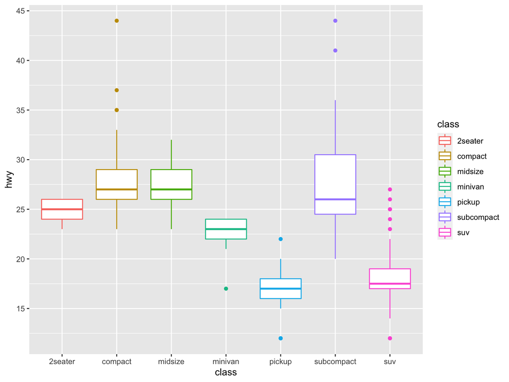

```r
ggplot(data=mpg)+
  geom_boxplot(mapping=aes(x=class,y=hwy,color=class))+
  scale_y_continuous(breaks=seq(0,45,5))
```

**12. Interchange the x and y variable. Explain what happens.**

We can trick the geom_boxplot() function into plotting a single variable by changing the numerical variable into a character.

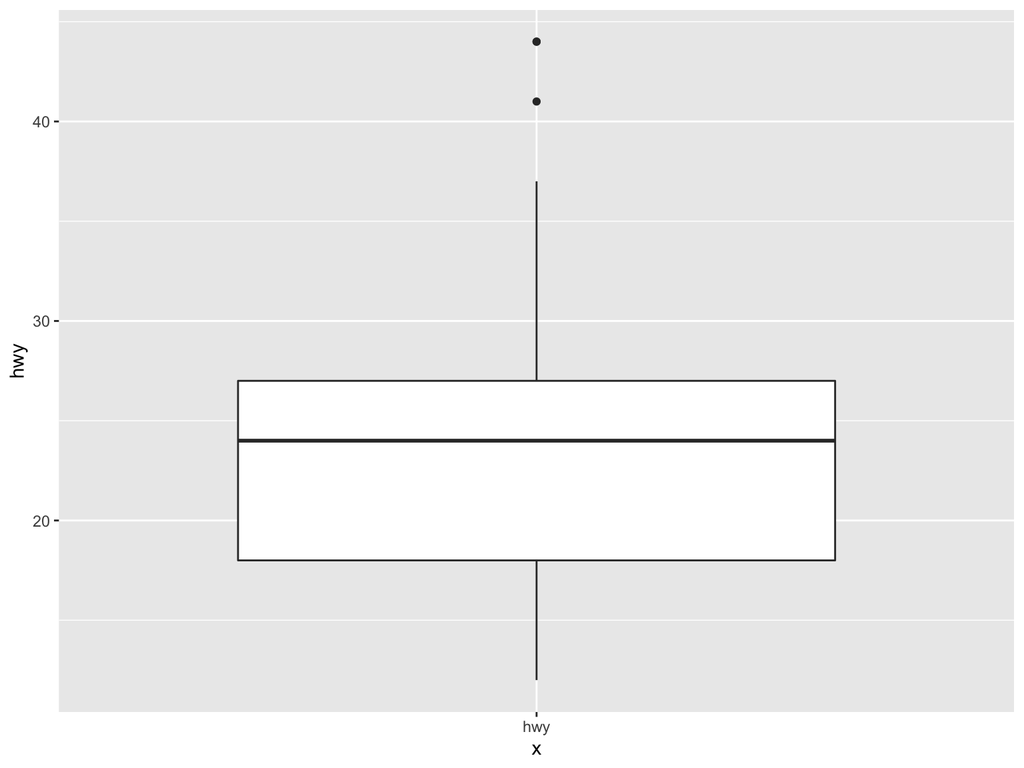

```r
ggplot(data=mpg)+
  geom_boxplot(mapping=aes(x="hwy",y=hwy))
```

**13. What code will create the visual below?**

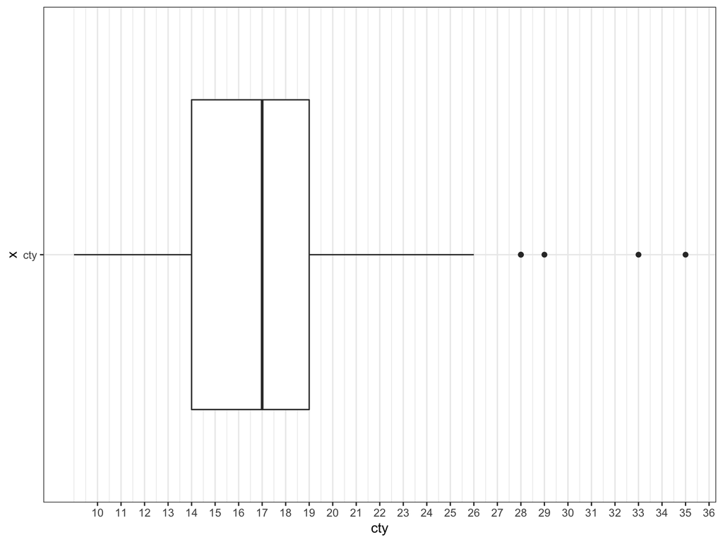

**CHEAT SHEET**

**continuous x, continuous y**

**Is there a difference between city miles per gallon and highway miles per gallon?**  
In order to help us answer this question we need to add the equation y = x to our scatterplot. The line y = x represents when hwy mileage = cty mileage (no difference).

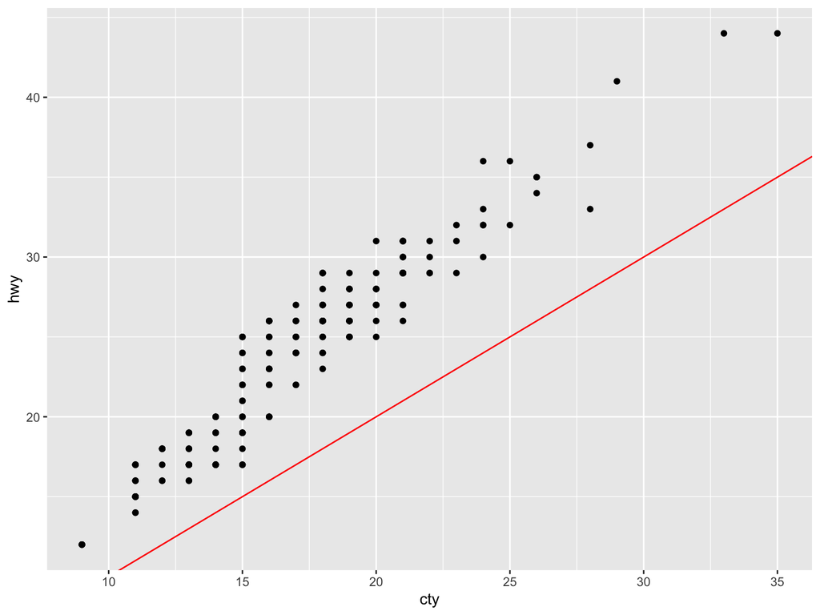

```r
ggplot(data=mpg)+
  geom_point(mapping=aes(x=cty,y=hwy))+
  geom_abline(intercept = 0, slope = 1, color="red")
```

**14. What code will create a scatterplot of hwy vs cty with the line of best fit?**

**What is the relationship between highway mileage and displacement?**

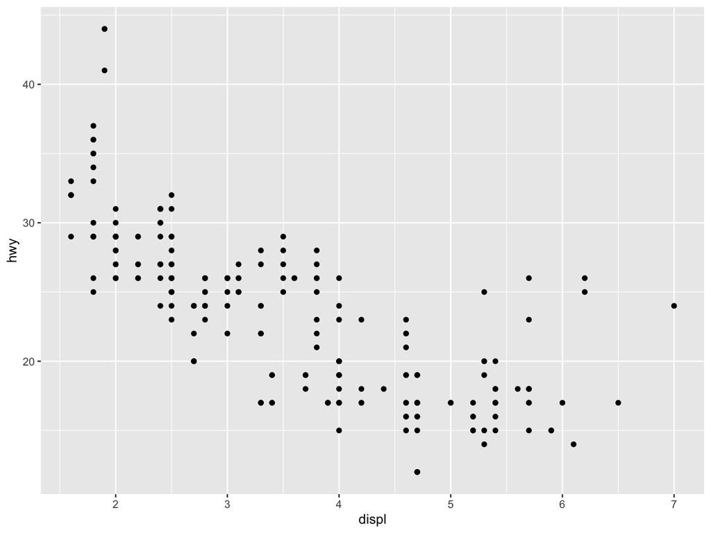

Notice that as engine displacement increases, highway miles per gallon decreases. There are a few observations, however, that don’t quite fit the pattern.

For those of you that want to learn about engine displacement, watch this short video:

[video not shown]

Try the codes below: determine which variable explains these outliers.

```r
ggplot(data=mpg)+
  geom_point(mapping=aes(x=displ,y=hwy,shape=cyl))
```

```r
ggplot(data=mpg)+
  geom_point(mapping=aes(x=displ,y=hwy,size=year))
```

```r
ggplot(data=mpg)+
  geom_point(mapping=aes(x=displ,y=hwy,color=fl))
```

```r
ggplot(data=mpg)+
  geom_point(mapping=aes(x=displ,y=hwy,color=class))
```

**15. What are the different aesthetics that can be applied to a geometric object (point)?**

# On Your Own

There are many more non-traditional plots that can be made using ggplot.

A 2d density chart displays the relationship between 2 numeric variables. One is represented on the X axis, the other on the Y axis, like for a scatterplot. Then, the number of observations within a particular area of the 2D space is counted and represented by a color gradient. Several types of 2d density charts exist.

**CHEAT SHEET**

**continuous bivariate distribution**

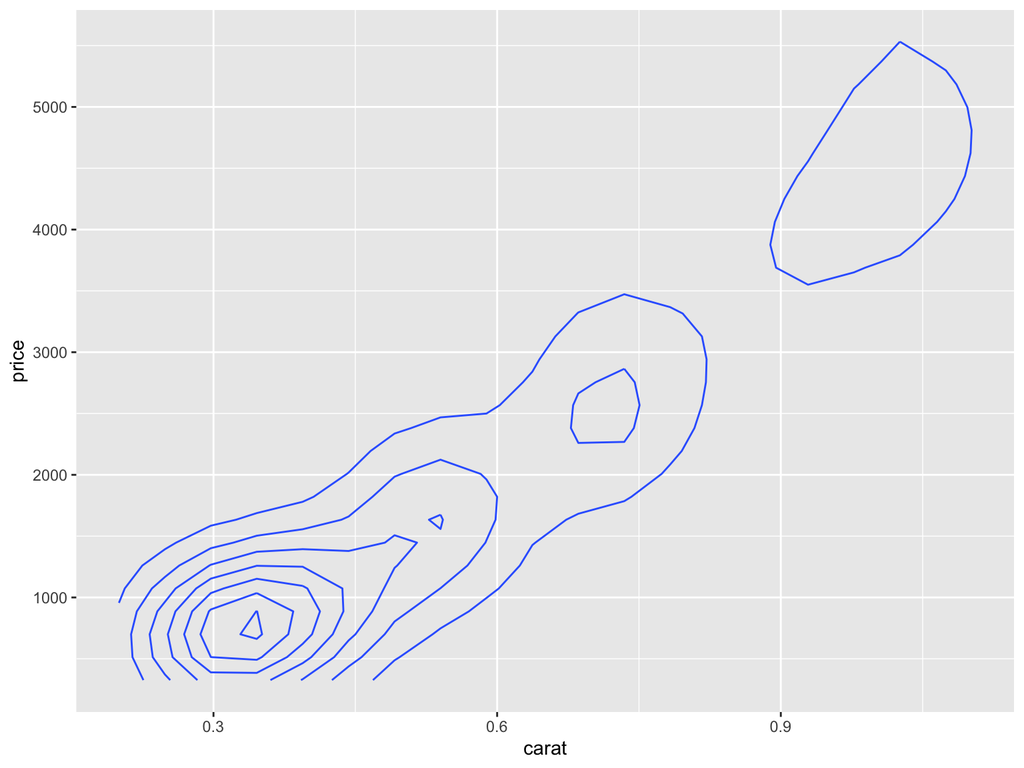

In order to create this graph notice on the cheat sheet it has `h + geom_density2d()`

Notice that `h` refers to `ggplot(diamonds,aes(carat,price))`

So the graph above was created using the following code:

```r
ggplot(diamonds,aes(carat,price))+
  geom_density2d()
```

This is equivalent to:

```r
ggplot(data=diamonds)+
  geom_density2d(mapping=aes(x=carat,y=price))
```

**16. Chose a different visualization from the ggplot cheat sheet to create.**